# Chapter 6 Multiple Regression I

Bryan Goodrich

2015-08-08

# Chapter 6 – Multiple Regression I

## Load the data sets

```r
library(lattice)
library(scatterplot3d)
library(rgl)
library(Rcmdr)
data("CH06FI05", package = "ALSM")
```

## Input the Dwaine Studios Data

```r
.data <- CH06FI05
names(.data) <- c("x1", "x2", "y")
fit <- lm(y ~ x1 + x2, .data)
```

## FIGURE 6.4 (p 232)

#### Scatter Plot Matrix and Correlation Matrix–Dwaine Studios Example

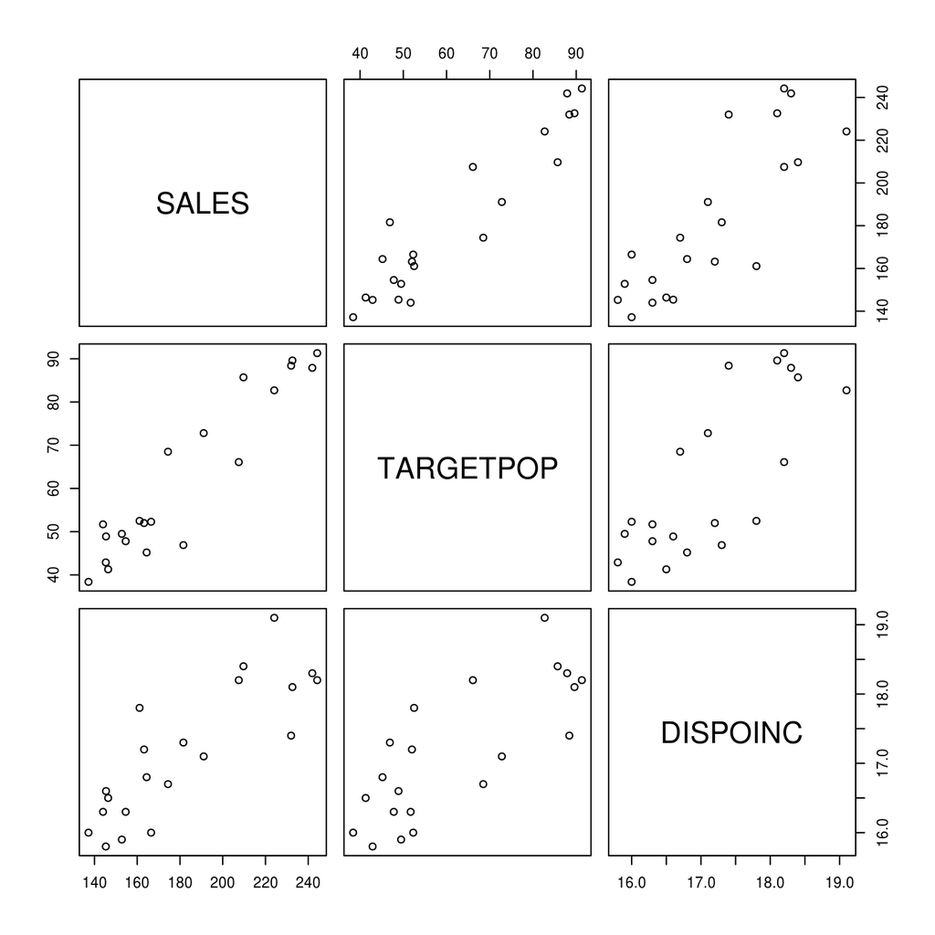

```r
with(.data, pairs(data.frame("SALES" = y, "TARGETPOP" = x1, "DISPOINC" = x2)))
```

```r
with(.data, cor  (data.frame("SALES" = y, "TARGETPOP" = x1, "DISPOINC" = x2)))
```

```
##            SALES TARGETPOP DISPOINC
## SALES     1.0000    0.9446   0.8358
## TARGETPOP 0.9446    1.0000   0.7813
## DISPOINC  0.8358    0.7813   1.0000
```

## FIGURE 6.5 (p 237)

#### Multiple Regression Output and Basic Data–Dwaine Studios Example

```r
cbind(
  "TARGETPOP (X1)" = .data$x1,
  "DISPOINC (X2)"  = .data$x2,
  "SALES (Y)"      = .data$y,
  "FITTED"         = round(fitted(fit),2),
  "RESIDUAL"       = round(resid(fit), 2))
```

```
##    TARGETPOP (X1) DISPOINC (X2) SALES (Y) FITTED RESIDUAL
## 1            68.5          16.7     174.4  187.2   -12.78
## 2            45.2          16.8     164.4  154.2    10.17
## 3            91.3          18.2     244.2  234.4     9.80
## 4            47.8          16.3     154.6  153.3     1.27
## 5            46.9          17.3     181.6  161.4    20.22
## 6            66.1          18.2     207.5  197.7     9.76
## 7            49.5          15.9     152.8  152.1     0.74
## 8            52.0          17.2     163.2  167.9    -4.67
## 9            48.9          16.6     145.4  157.7   -12.34
## 10           38.4          16.0     137.2  136.8     0.35
## 11           87.9          18.3     241.9  230.4    11.51
## 12           72.8          17.1     191.1  197.2    -6.08
## 13           88.4          17.4     232.0  222.7     9.31
## 14           42.9          15.8     145.3  141.5     3.78
## 15           52.5          17.8     161.1  174.2   -13.11
## 16           85.7          18.4     209.7  228.1   -18.42
## 17           41.3          16.5     146.4  145.8     0.65
## 18           51.7          16.3     144.0  159.0   -15.00
## 19           89.6          18.1     232.6  231.0     1.61
## 20           82.7          19.1     224.1  230.3    -6.22
## 21           52.3          16.0     166.5  157.1     9.44
```

```r
summary(fit)
```

```
##
## Call:
## lm(formula = y ~ x1 + x2, data = .data)
##
## Residuals:
##     Min      1Q  Median      3Q     Max
## -18.424  -6.216   0.745   9.436  20.215
##
## Coefficients:
##             Estimate Std. Error t value Pr(>|t|)
## (Intercept)  -68.857     60.017   -1.15    0.266
## x1             1.455      0.212    6.87 0.000002 ***
## x2             9.366      4.064    2.30    0.033 *
## ---
## Signif. codes:  0 '***' 0.001 '**' 0.01 '*' 0.05 '.' 0.1 ' ' 1
##
## Residual standard error: 11 on 18 degrees of freedom
## Multiple R-squared:  0.917,  Adjusted R-squared:  0.907
## F-statistic: 99.1 on 2 and 18 DF,  p-value: 1.92e-10
```

```r
anova(fit)
```

```
## Analysis of Variance Table
##
## Response: y
##           Df Sum Sq Mean Sq F value  Pr(>F)
## x1         1  23372   23372  192.90 4.6e-11 ***
## x2         1    643     643    5.31   0.033 *
## Residuals 18   2181     121
## ---
## Signif. codes:  0 '***' 0.001 '**' 0.01 '*' 0.05 '.' 0.1 ' ' 1
```

## FIGURE 6.6 (p 238)

#### Plot of Point Clound before and after Spinning–Dwaine Studios Example

Since *lattice* is a popular library, I decided to use `cloud` for this task. There are other libaries such as *scatterplot3d*, *rgl* and *Rcmdr* that include their own methods.

To rotate the cloud we use the `screen` parameter that takes a list of the position angles of the coordinate axes. The default screen value is

> `screen = list(z = 40, x = -60, y = 0)`

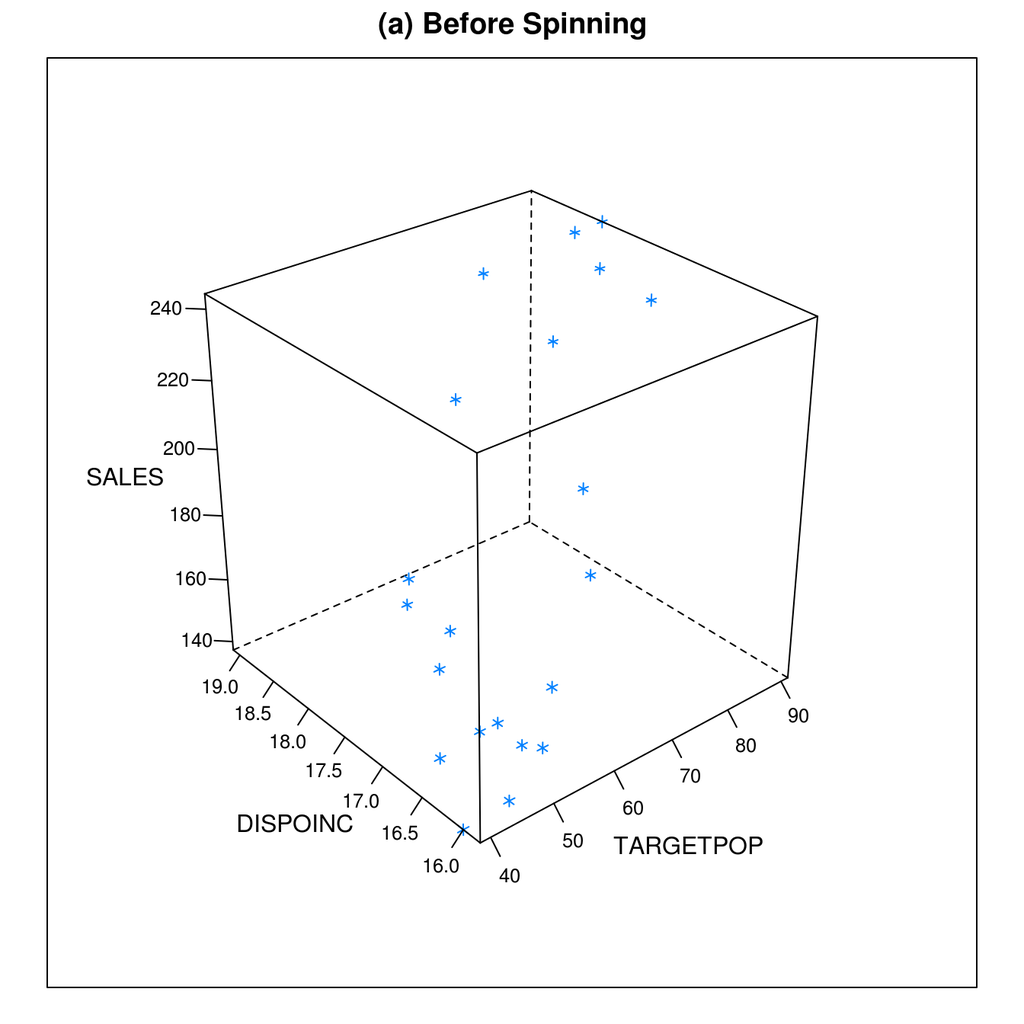

```r
library(lattice)
cloud(y ~ x1 + x2, .data, scales = list(arrows = FALSE),
      xlab = "TARGETPOP", ylab = "DISPOINC", zlab = "SALES",
      main = "(a) Before Spinning")
```

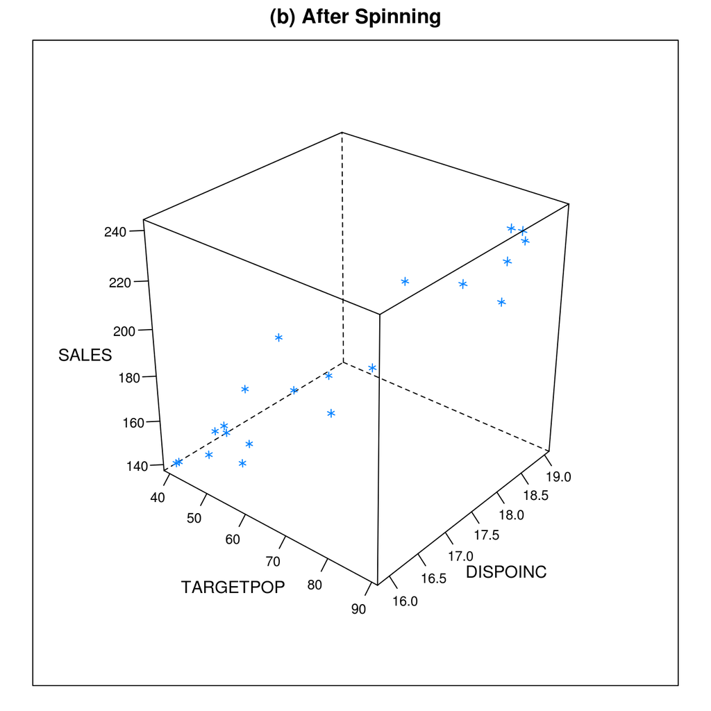

```r
cloud(y ~ x1 + x2, .data, scales = list(arrows = FALSE),
      xlab = "TARGETPOP", ylab = "DISPOINC", zlab = "SALES",
      main = "(b) After Spinning", screen = list(z = -40, x = -60, y = 0))
```

## FIGURE 6.7 (p 240)

#### Plot of Estimated Regression Surface–Dwaine Studios Example

The approach below uses a *base* R graphics function `persp` used in 3D plotting. The approach is simple in that you create 2 sorted sequences, one for each independent variable, both of equal length. You then expand a grid of all combinations of these sequences and use the linear model to predict the values for each of these combinations to create a new sequence. These 3 sequences are then input to `persp` to define how to draw the 3D plot along the dimensions of those sequences.

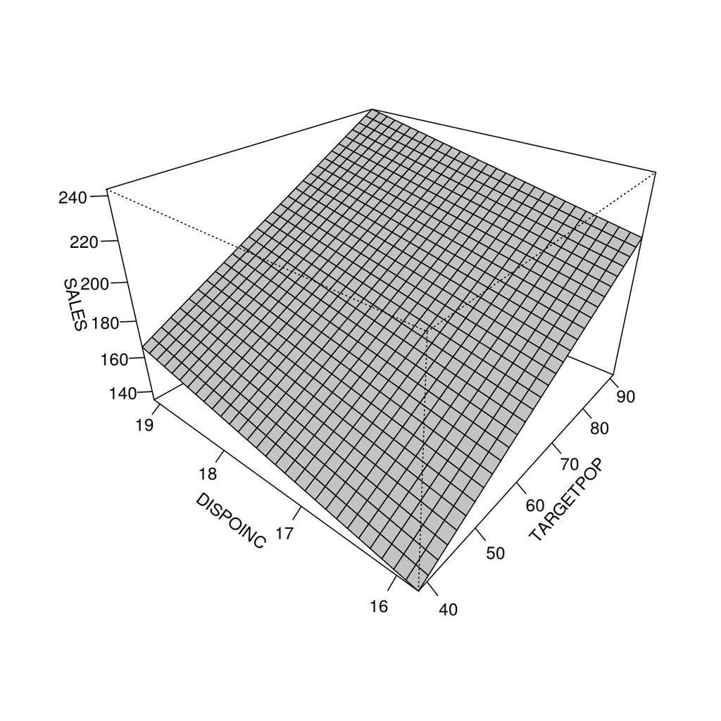

```r
lm3d <- function(model, res, ...) {
  ivs <- labels(terms(model))
  x <- model.frame(model)[, ivs[1]]     # 1st independent variable
  y <- model.frame(model)[, ivs[2]]     # 2nd independent variable
  xr <- seq(min(x), max(x), len = res)  # equidistant sequence from range of 1st iv
  yr <- seq(min(y), max(y), len = res)  # equidistant sequence from range of 2nd iv

  # Create a list object of these sequences to be turned into a grid
  newdata <- list(xr, yr)
  names(newdata) <- ivs
  newdata <- do.call('expand.grid', newdata)

  zr <- matrix(predict(model, newdata), res, res)
  persp(xr, yr, zr, ...)
}

# The resolution ('res') parameter controls how 'fine' the plane is
lm3d(fit, res = 30,
     ticktype = "detailed", shade = 0.5, expand = 2/3,
     xlab = "TARGETPOP", ylab = "DISPOINC", zlab = "SALES",
     theta = 310, phi = 30)
```

While this provides a static view of fitted plane, it is possible to ‘animate’ a rotation with a little trickery. The interested reader should do something like the following.

```r
# Change "len = 24" lower or higher for larger or smaller rotations
for (t in seq(0, 360, len = 24))
{
  lm3d(fit, 25, ..., theta = t)  # change phi for z-rotation
  Sys.sleep(0.1)                 # How many seconds to delay before rotating
}
```

## FIGURE 6.8 (p 242)

#### Diagnostic Plots–Dwaine Studios Example

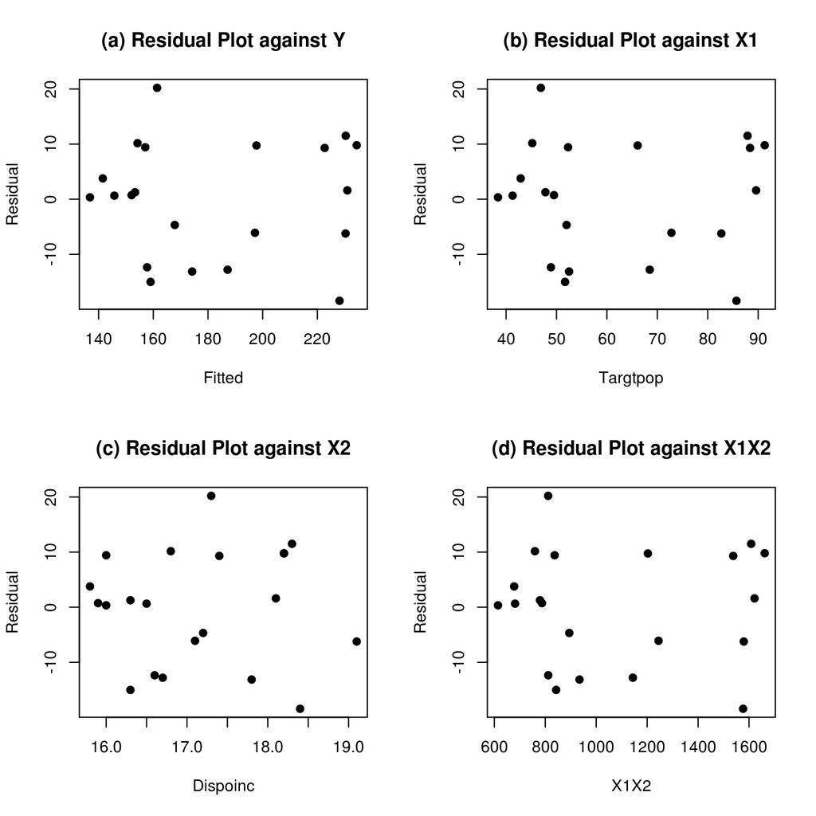

```r
par(mfrow = c(2, 2), pch = 19)
plot(resid(fit) ~ fitted(fit), xlab = "Fitted", ylab = "Residual")
title("(a) Residual Plot against Y")

plot(resid(fit) ~ x1, .data, xlab = "Targtpop", ylab = "Residual")
title("(b) Residual Plot against X1")

plot(resid(fit) ~ x2, .data, xlab = "Dispoinc", ylab = "Residual")
title("(c) Residual Plot against X2")

plot(resid(fit) ~ I(x1 * x2), .data, xlab = "X1X2", ylab = "Residual")
title("(d) Residual Plot against X1X2")
```

## FIGURE 6.9 (p 243)

#### Additional Diagnotic Plots–Dwaine Studios Example

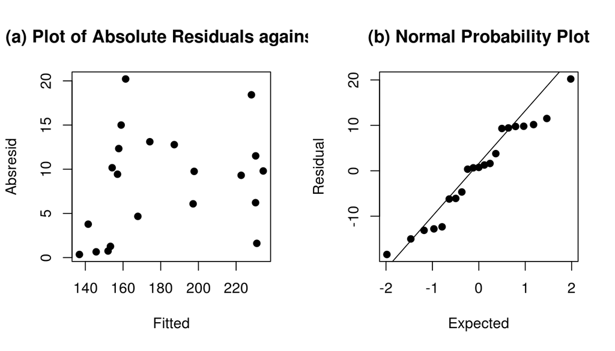

```r
par(mfrow = c(1, 2), pch = 19)
plot(abs(resid(fit)) ~ fitted(fit), xlab = "Fitted", ylab = "Absresid")
title("(a) Plot of Absolute Residuals against Y")

qqnorm(resid(fit), main = "", xlab = "Expected", ylab = "Residual")
qqline(resid(fit))
title("(b) Normal Probability Plot")
```

## Estimation of Regression Parameters (p 245)

#### See Ch. 4 walk-through for why the default confint level = 0.95 is alright.

```r
confint(fit)
```

```
##                 2.5 % 97.5 %
## (Intercept) -194.9480 57.234
## x1             1.0096  1.899
## x2             0.8274 17.904
```

## Estimation of Mean Response (p 246)

```r
predict(fit, data.frame(x1 = 65.4, x2 = 17.6), interval = "confidence")
```

```
##     fit   lwr   upr
## 1 191.1 185.3 196.9
```

## Prediction Limits for New Observations (p 247)

#### Scheffe and Bonferroni Procedures

The `ci.sim` from Ch. 4 handles this multivariate case without change.

```r
ci.sim <- function(model, newdata, type = c("B", "S"), alpha = 0.05)
{
  g  <- nrow(newdata)
  CI <- predict(model, newdata, se.fit = TRUE)
  M  <- ifelse(match.arg(type) == "B",
          qt(1 - alpha / (2*g), model$df),              # B = (4.9a)
          sqrt(g * qf(1 - alpha, g, model$df)))         # S = (4.8a)

  spred <- sqrt( CI$residual.scale^2 + (CI$se.fit)^2 )  #     (2.38)
  x <- data.frame(
    "x"     = newdata,
    "spred" = spred,
    "fit"   = CI$fit,
    "lower" = CI$fit - M * spred,
    "upper" = CI$fit + M * spred)

  return(x)
}

newdata <- data.frame( x1 = c(65.4, 53.1), x2 = c(17.6, 17.7) )
ci.sim(fit, newdata, "B", 0.1)  # Bonferroni Prediction
```

```
##   x.x1 x.x2 spred   fit lower upper
## 1 65.4 17.6 11.35 191.1 167.3 214.9
## 2 53.1 17.7 11.93 174.1 149.1 199.2
```

```r
ci.sim(fit, newdata, "S", 0.1)  # Scheffe Prediction
```

```
##   x.x1 x.x2 spred   fit lower upper
## 1 65.4 17.6 11.35 191.1 165.1 217.1
## 2 53.1 17.7 11.93 174.1 146.8 201.5
```